# Life Satisfaction in South America

COMP/STAT 112 Final Project Blog

Maya Harrison, Flor Perez Nunez, Inbal Armony

2023-12-19

When you think about your life, what influences your life satisfaction the most? Is it your friends and family, your job, or maybe even economic stability? Would the people around you answer the same thing?

In a joint research project called the Latin American Public Opinion Project (LAPOP), USAID, and Vanderbilt University surveyed citizens of 28 Latin American countries using a national probability design. In one question the researchers asked participants, “In general, how satisfied are you with your life?” Over 10 years (2004-2014) voting-age adults responded to this question, along with questions about their impressions of their nation’s economic situation, democracy, basic rights, and many other topics.

Looking through the data, we narrowed down the data set to the eleven surveyed countries in South America. After several conversations comparing our experiences in the United States with life experiences in South America, our group was curious to find out what determines life satisfaction in South American countries. And more specifically, between perceptions of basic rights, democracy, and the economic situation, which most correlates to life satisfaction? For these questions, each country had between 1,100 and 3,000 respondents per year.

#### Life satisfaction differs throughout South America

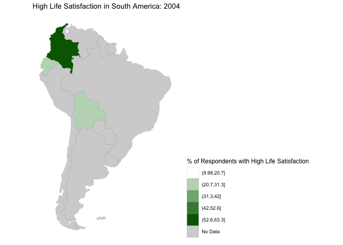

The map provides important geographic information that could impact life satisfaction, like coastal versus land-locked countries and possible relationships between neighboring countries. This map portrays some interesting geographic trends in this data like the Northern and warmest countries of the continent (Brazil, Colombia, and Venezuela) consistently having higher percentages of high life satisfaction over time. In contrast, between 2008-2012, southern countries like Bolivia, Chile, and Peru had much fewer respondents with high life satisfaction.

#### Every South American country experiences fluctuations in life satisfaction over time

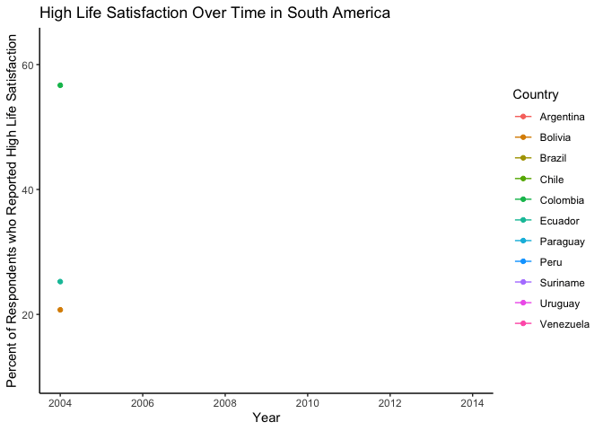

Our next graph displays the same data as the previous map––percentages of respondents reporting high life satisfaction––but shown on a scatter plot that is animated over time. Each individual country is represented by its own, different colored line and the animation helps highlight change over time of life satisfaction. This visualization helps with comparisons between nations as we can easily see when one nation has a greater portion of respondents with high life satisfaction than another nation.

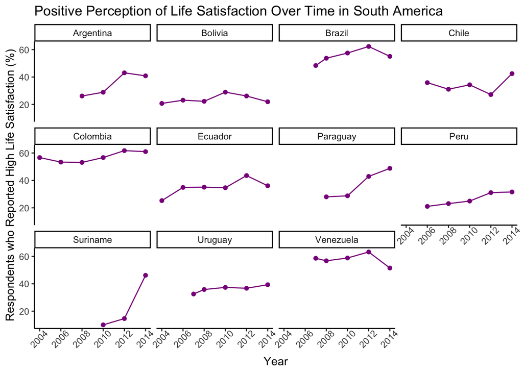

#### Perceptions of life satisfaction and the economy change together

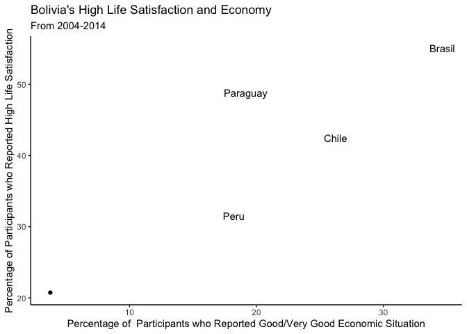

Upon looking closely at Bolivia’s percentage of high life satisfaction and the perception of a favorable economic situation, a pattern emerges. Initially, both indicators experienced an upward trajectory, signaling positive trends. However, in the subsequent period, there was a noticeable decline in both measures. The perception of the economic situation improved, with an increase of approximately 25 percentage points. This suggests a positive shift in the way individuals in Bolivia perceive their economic circumstances. Simultaneously, life satisfaction showed an increase of around 10 percentage points, indicating an overall positive sentiment among the populace. When juxtaposed with neighboring countries, Bolivia’s standings in both categories are comparatively lower. This implies that, despite the observed improvements, Bolivia stays behind its regional counterparts in terms of both economic optimism and overall life satisfaction.

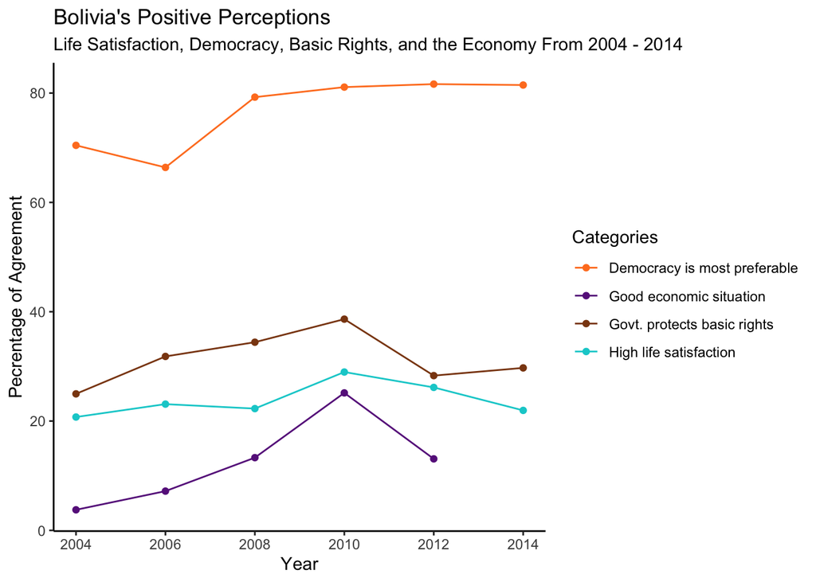

This observation gains significance when considering the Bolivian presidential election in 2005, resulting in the election of a new president, Evo Morales. Between 2010 and 2012, there was a decline in life satisfaction, perceptions of a good economic situation, and confidence in the government’s protection of basic rights. Interestingly, the perception of democracy as the preferred form of government remained stable. The decrease in these three perceptions aligns with the political and economic instability during that period. In 2008, an economic crisis hit Bolivia and other South American countries. Simultaneously, there was political instability marked by protests against President Morales, escalating into the Porvenir massacre as a consequence of violent right-wing protests.

#### Conclusion

Overall, between democracy, basic rights, and the economy, no single perception determines life satisfaction in South America. However, exploring individual countries in depth, as we did with Bolivia, reveals interesting relationships between the perceptions.

It is critical to note that these data points represent the lived experiences of real people. Complex experiences cannot be accurately quantified or generalized for an entire country, making this dataset inherently flawed. The conclusions we drew about life satisfaction in Latin America provide important starting off points for more research but cannot be taken as conclusive evidence. Rather, we hope to honor these real experiences by presenting the complexities of the question of life satisfaction.

Bolivia’s lower rates of high life satisfaction, by comparison with other nations in South America, must be understood within the country’s complex political and economic landscape. The similar changes in perceptions of life satisfaction, basic rights, and the economy provide insight into the impact of intense moments of political strife and economic crisis. More specific perceptions and factors––such as Bolivia being a landlocked country, or ratings of Morales over time––should be explored in future research to better understand the issues more impacting Bolivians.

#### References:

Congressional Research Service. (n. d.) https://crsreports.congress.gov/product/pdf/IF/IF11325

Center for Economic and Policy Research. (2019). Bolivia’s Macroeconomic Situation. https://cepr.net/images/stories/reports/bolivia-macro-2019-10.pdf

Thomson, S., Barragán, R., Albó, X., Qayum, S., & Goodale, M. (Eds.). (2018). The Bolivia Reader: History, Culture, Politics. Duke University Press. https://doi.org/10.2307/j.ctv11313s0

Vanderbilt University. (n.d.). Latin American Public Opinion Project (LAPOP) Survey Data. Retrieved from https://www.vanderbilt.edu/lapop/survey-data.php